# CTD Lab Exercise

Lillian Thistlethwaite

3/6/2019

This document was rendered at 2019-03-08 13:10:53

# I. Generate background knowledge graph.

## I.I: Manually build graphs from adjacency matrices.

[figure not shown]

Figure 1. Cartoon of graph we will build manually via its adjacency matrix.

```r
adj_mat = rbind(c(0,3,1,0,0,0,0,0,0), #A's neighbors
                c(3,0,2,2,0,0,0,0,0), #B's neighbors
                c(1,2,0,0,2,0,0,0,0), #C's neighbors
                c(0,2,0,0,1,0,1,1,0), #D's neighbors
                c(0,0,2,1,0,2,0,2,0), #E's neighbors
                c(0,0,0,0,2,0,0,0,0), #F's neighbors
                c(0,0,0,1,0,0,0,1,0), #G's neighbors
                c(0,0,0,1,2,0,1,0,1), #H's neighbors
                c(0,0,0,0,0,0,0,1,0) #I's neighbors
                )
rownames(adj_mat) = c("A", "B", "C", "D", "E", "F", "G", "H", "I")
colnames(adj_mat) = c("A", "B", "C", "D", "E", "F", "G", "H", "I")
# Convert adjacency matrices to igrpah objects for all three graphs.
ig = graph.adjacency(adj_mat, mode="undirected", weighted=TRUE, add.colnames = "name")
print(ig)
```

```
## IGRAPH cd38506 UNW- 9 12 --
## + attr: name (v/c), weight (e/n)
## + edges from cd38506 (vertex names):
##  [1] A--B A--C B--C B--D C--E D--E D--G D--H E--F E--H G--H H--I
```

## I.II: Learn a graph from data.

```r
# Load the Miller2015_Heparin dataset
data(Miller2015_Heparin)
data(heparin_metabolites)
metClass = heparin_metabolites[,"SUPERPATHWAY"]
data = Miller2015_Heparin
# Only include metabolites that are present in >90% reference samples.
fil.rate = data[,"FillRate"]
data = data[which(fil.rate>0.90),-c(1,2,3)]
metClass = metClass[which(fil.rate>0.90)]
#dim(data)
#length(metClass)
# Remove all Xenobiotics
#rownames(data)[which(metClass=="Xenobiotics")]
data = data[-which(metClass=="Xenobiotics"),]
# Remove any metabolites where any profile has a z-score > 1000. These are likely imputed raw values that were not z-scored.
rmMets = names(which(apply(data, 1, function(i) any(i>20))))
if (length(rmMets)>0) {
  data = data[-which(rownames(data) %in% rmMets),]
}
#dim(data)

# Get the diagnoses associated with the samples
diag = colnames(data)
diag = gsub("[[:digit:]]", "", diag)
# Collapse cobalamin deficiency subtypes into one category CBL
diag[grep("cbl.a|CBLC", diag)] = "CBL"
# Look at the diagnoses available
diagnoses = data.frame(id=colnames(data), diagnosis=diag)
#table(diagnoses$diagnosis)
ind.nones = which(diagnoses$diagnosis=="None")

# Get data from all patients with Argininemia
arg_data = data[,which(diagnoses$diagnosis=="Argininemia")]
# Add surrogate disease and surrogate reference profiles based on 1 standard deviation around profiles from real patients to improve rank of matrix when learning Gaussian Markov Random Field network on data.
arg_data = data.surrogateProfiles(arg_data, 1, TRUE, ref_data = data[,ind.nones])
#dim(arg_data)

# Learn a Gaussian Markov Random Field model using the Graphical LASSO in the R package "huge".
# Select the regularization parameter based on the "STARS" stability estimate.
require(huge)
#This will take 30 seconds - 1 minute.
arg = huge(t(arg_data), method="glasso")
```

```
## Conducting the graphical lasso (glasso) with lossless screening....in progress:0%
Conducting the graphical lasso (glasso) with lossless screening....in progress:9%
Conducting the graphical lasso (glasso) with lossless screening....in progress:19%
Conducting the graphical lasso (glasso) with lossless screening....in progress:30%
Conducting the graphical lasso (glasso) with lossless screening....in progress:40%
Conducting the graphical lasso (glasso) with lossless screening....in progress:50%
Conducting the graphical lasso (glasso) with lossless screening....in progress:60%
Conducting the graphical lasso (glasso) with lossless screening....in progress:70%
Conducting the graphical lasso (glasso) with lossless screening....in progress:80%
Conducting the graphical lasso (glasso)....done.
```

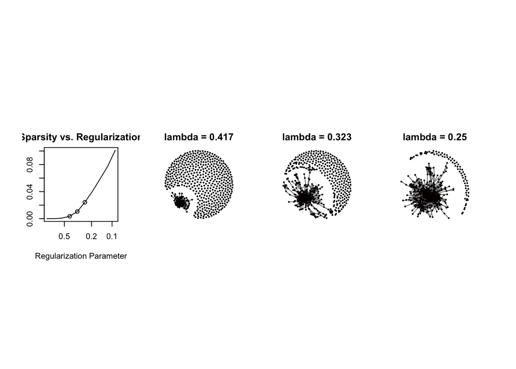

```r
plot(arg)
```

```r
# This will take 3-5-ish minutes.
#arg.select = huge.select(arg, criterion="stars")
#plot(arg.select)
# This is the regularization parameter the STARS method selected.
#print(arg.select$opt.lambda)
# This is the corresponding inverse of the covariance matrix that corresponds to the selected regularization level.
#arg_icov = as.matrix(arg.select$opt.icov)
arg_icov = as.matrix(arg$icov[[6]])
# Remove all "self" edges, as we are not interested in self-relationships.
diag(arg_icov) = 0
rownames(arg_icov) = rownames(arg_data)
colnames(arg_icov) = rownames(arg_data)
# Convert adjacency matrices to an igraph object.
ig_arg = graph.adjacency(arg_icov, mode="undirected", weighted=TRUE, add.colnames = "name")
print(ig_arg)
```

```
## IGRAPH c8709d9 UNW- 606 4450 --
## + attr: name (v/c), weight (e/n)
## + edges from c8709d9 (vertex names):
##  [1] 3-hydroxypropanoate--x-17305
##  [2] 3-hydroxypropanoate--x-15472
##  [3] 3-hydroxypropanoate--n-acetylserine
##  [4] 3-hydroxypropanoate--erythronate
##  [5] 3-hydroxypropanoate--n-acetylglutamine
##  [6] 3-hydroxypropanoate--pantothenate (vitamin b5)
##  [7] 3-hydroxypropanoate--cytidine
##  [8] 3-hydroxypropanoate--propionylcarnitine (c3)
## + ... omitted several edges
```

# II. The Probability Diffusion Algorithm

## II.I From a starting node.

Run the following code, then go to the directory, and open all diffusionEventMovie*.png files all at once. Starting from the first image, view how the probability diffusion algorithm works to diffuse 100% probability to the rest of the graph. Be sure to pay attention to the recursion level listed in the title of each image, to imagine where in the call stack the algorithm is at the captured time the image was generated.

```r
# Set some global parameters for the Probability Diffusion Algorithm.
p0=0.1
p1=0.9
thresholdDiff=0.01

G=vector(mode="list", length=length(V(ig)$name))
G[1:length(G)] = 0
names(G) = c("A", "B", "C", "D", "E", "F", "G", "H", "I")
startNode = "A"
visitedNodes = startNode
# Diffuse 100% of probability from startNode "A"
p1 = 1.0
# Probability diffusion truncates at
thresholdDiff=0.01
coords = layout.fruchterman.reingold(ig)
V(ig)$x = coords[,1]
V(ig)$y = coords[,2]
# Global variable imgNum
imgNum=1
G_new = graph.diffuseP1Movie(p1, startNode, G, visitedNodes, ig, recursion_level=1, output_dir = "/Users/lillian.rosa/Downloads/CTD/vignette/diffusion_event")
```

```
## [1] "prob. to diffuse:1.000000 startNode: A, visitedNodes: A"
## [1] "ImgNum=1"
```

```
## [1] "Weighted_edges.sum=4.000000"
## [1] "added diffused  probability 0.750000 to child #1: B"
```

```
## [1] "subtracted 0.375000 from startNode's neighbor #1: B and sent to its own neighbors."
```

```
## [1] "   prob. to diffuse:0.375000 startNode: B, visitedNodes: A, B"
## [1] "ImgNum=4"
```

```
## [1] "   Weighted_edges.sum=4.000000"
## [1] "   added diffused  probability 0.187500 to child #1: C"
```

```
## [1] "   subtracted 0.093750 from startNode's neighbor #1: C and sent to its own neighbors."
```

```
## [1] "      prob. to diffuse:0.093750 startNode: C, visitedNodes: A, B, C"
## [1] "ImgNum=7"
```

```
## [1] "      Weighted_edges.sum=2.000000"
## [1] "      added diffused  probability 0.093750 to child #1: E"
```

```
## [1] "      subtracted 0.046875 from startNode's neighbor #1: E and sent to its own neighbors."
```

```
## [1] "         prob. to diffuse:0.046875 startNode: E, visitedNodes: A, B, C, E"
## [1] "ImgNum=10"
```

```
## [1] "         Weighted_edges.sum=5.000000"
## [1] "         added diffused  probability 0.009375 to child #1: D"
```

```
## [1] "         added diffused  probability 0.018750 to child #2: F"
```

```
## [1] "         added diffused  probability 0.018750 to child #3: H"
```

```
## [1] "   added diffused  probability 0.187500 to child #2: D"
```

```
## [1] "   subtracted 0.093750 from startNode's neighbor #2: D and sent to its own neighbors."
```

```
## [1] "      prob. to diffuse:0.093750 startNode: D, visitedNodes: A, B, D"
## [1] "ImgNum=18"
```

```
## [1] "      Weighted_edges.sum=3.000000"
## [1] "      added diffused  probability 0.031250 to child #1: E"
```

```
## [1] "      subtracted 0.015625 from startNode's neighbor #1: E and sent to its own neighbors."
```

```
## [1] "         prob. to diffuse:0.015625 startNode: E, visitedNodes: A, B, D, E"
## [1] "ImgNum=21"
```

```
## [1] "         Weighted_edges.sum=6.000000"
## [1] "         added diffused  probability 0.005208 to child #1: C"
```

```
## [1] "         added diffused  probability 0.005208 to child #2: F"
```

```
## [1] "         added diffused  probability 0.005208 to child #3: H"
```

```
## [1] "      added diffused  probability 0.031250 to child #2: G"
```

```
## [1] "      subtracted 0.015625 from startNode's neighbor #2: G and sent to its own neighbors."
```

```
## [1] "         prob. to diffuse:0.015625 startNode: G, visitedNodes: A, B, D, G"
## [1] "ImgNum=28"
```

```
## [1] "         Weighted_edges.sum=1.000000"
## [1] "         added diffused  probability 0.015625 to child #1: H"
```

```
## [1] "      added diffused  probability 0.031250 to child #3: H"
```

```
## [1] "      subtracted 0.015625 from startNode's neighbor #3: H and sent to its own neighbors."
```

```
## [1] "         prob. to diffuse:0.015625 startNode: H, visitedNodes: A, B, D, H"
## [1] "ImgNum=33"
```

```
## [1] "         Weighted_edges.sum=4.000000"
## [1] "         added diffused  probability 0.007812 to child #1: E"
```

```
## [1] "         added diffused  probability 0.003906 to child #2: G"
```

```
## [1] "         added diffused  probability 0.003906 to child #3: I"
```

```
## [1] "added diffused  probability 0.250000 to child #2: C"
```

```
## [1] "subtracted 0.125000 from startNode's neighbor #2: C and sent to its own neighbors."
```

```
## [1] "   prob. to diffuse:0.125000 startNode: C, visitedNodes: A, C"
## [1] "ImgNum=42"
```

```
## [1] "   Weighted_edges.sum=4.000000"
## [1] "   added diffused  probability 0.062500 to child #1: B"
```

```
## [1] "   subtracted 0.031250 from startNode's neighbor #1: B and sent to its own neighbors."
```

```
## [1] "      prob. to diffuse:0.031250 startNode: B, visitedNodes: A, C, B"
## [1] "ImgNum=45"
```

```
## [1] "      Weighted_edges.sum=2.000000"
## [1] "      added diffused  probability 0.031250 to child #1: D"
```

```
## [1] "      subtracted 0.015625 from startNode's neighbor #1: D and sent to its own neighbors."
```

```
## [1] "         prob. to diffuse:0.015625 startNode: D, visitedNodes: A, C, B, D"
## [1] "ImgNum=48"
```

```
## [1] "         Weighted_edges.sum=3.000000"
## [1] "         added diffused  probability 0.005208 to child #1: E"
```

```
## [1] "         added diffused  probability 0.005208 to child #2: G"
```

```
## [1] "         added diffused  probability 0.005208 to child #3: H"
```

```
## [1] "   added diffused  probability 0.062500 to child #2: E"
```

```
## [1] "   subtracted 0.031250 from startNode's neighbor #2: E and sent to its own neighbors."
```

```
## [1] "      prob. to diffuse:0.031250 startNode: E, visitedNodes: A, C, E"
## [1] "ImgNum=56"
```

```
## [1] "      Weighted_edges.sum=5.000000"
## [1] "      added diffused  probability 0.006250 to child #1: D"
```

```
## [1] "      added diffused  probability 0.012500 to child #2: F"
```

```
## [1] "      added diffused  probability 0.012500 to child #3: H"
```

```r
# Inherited probabilities across all nodes should add to 1.
sum(unlist(G_new))
```

```
## [1] 1
```

```r
# Which node inherited the highest probability from startNode?
G_new[which.max(G_new)]
```

```
## $B
## [1] 0.40625
```

## II.II From a starting node, after visiting previous nodes.

Now, delete all diffusionEventMovie*.png files from your current directory, and run the following code. View the new image stack in the same way we did previously.

```r
# Now let's see how the probability diffusion algorithm diffuses probability after B has been "stepped" into.
visitedNodes = c("A", "B")
startNode = "B"
imgNum=1

G_new = graph.diffuseP1Movie(p1, startNode, G, visitedNodes, ig, 1, output_dir = "/Users/lillian.rosa/Downloads/CTD/vignette/diffusion_event2")
```

```
## [1] "   prob. to diffuse:1.000000 startNode: B, visitedNodes: A, B"
## [1] "ImgNum=1"
```

```
## [1] "   Weighted_edges.sum=4.000000"
## [1] "   added diffused  probability 0.500000 to child #1: C"
```

```
## [1] "   subtracted 0.250000 from startNode's neighbor #1: C and sent to its own neighbors."
```

```
## [1] "      prob. to diffuse:0.250000 startNode: C, visitedNodes: A, B, C"
## [1] "ImgNum=4"
```

```
## [1] "      Weighted_edges.sum=2.000000"
## [1] "      added diffused  probability 0.250000 to child #1: E"
```

```
## [1] "      subtracted 0.125000 from startNode's neighbor #1: E and sent to its own neighbors."
```

```
## [1] "         prob. to diffuse:0.125000 startNode: E, visitedNodes: A, B, C, E"
## [1] "ImgNum=7"
```

```
## [1] "         Weighted_edges.sum=5.000000"
## [1] "         added diffused  probability 0.025000 to child #1: D"
```

```
## [1] "         subtracted 0.012500 from startNode's neighbor #1: D and sent to its own neighbors."
```

```
## [1] "            prob. to diffuse:0.012500 startNode: D, visitedNodes: A, B, C, E, D"
## [1] "ImgNum=10"
```

```
## [1] "            Weighted_edges.sum=2.000000"
## [1] "            added diffused  probability 0.006250 to child #1: G"
```

```
## [1] "            added diffused  probability 0.006250 to child #2: H"
```

```
## [1] "         added diffused  probability 0.050000 to child #2: F"
```

```
## [1] "         subtracted 0.025000 from startNode's neighbor #2: F and sent to its own neighbors."
```

```
## [1] "            prob. to diffuse:0.025000 startNode: F, visitedNodes: A, B, C, E, F"
## [1] "ImgNum=16"
```

```
## [1] "            Weighted_edges.sum=3.000000"
## [1] "            added diffused  probability 0.008333 to child #1: D"
```

```
## [1] "            added diffused  probability 0.016667 to child #2: H"
```

```
## [1] "         added diffused  probability 0.050000 to child #3: H"
```

```
## [1] "         subtracted 0.025000 from startNode's neighbor #3: H and sent to its own neighbors."
```

```
## [1] "            prob. to diffuse:0.025000 startNode: H, visitedNodes: A, B, C, E, H"
## [1] "ImgNum=22"
```

```
## [1] "            Weighted_edges.sum=3.000000"
## [1] "            added diffused  probability 0.008333 to child #1: D"
```

```
## [1] "            added diffused  probability 0.008333 to child #2: G"
```

```
## [1] "            added diffused  probability 0.008333 to child #3: I"
```

```
## [1] "   added diffused  probability 0.500000 to child #2: D"
```

```
## [1] "   subtracted 0.250000 from startNode's neighbor #2: D and sent to its own neighbors."
```

```
## [1] "      prob. to diffuse:0.250000 startNode: D, visitedNodes: A, B, D"
## [1] "ImgNum=31"
```

```
## [1] "      Weighted_edges.sum=3.000000"
## [1] "      added diffused  probability 0.083333 to child #1: E"
```

```
## [1] "      subtracted 0.041667 from startNode's neighbor #1: E and sent to its own neighbors."
```

```
## [1] "         prob. to diffuse:0.041667 startNode: E, visitedNodes: A, B, D, E"
## [1] "ImgNum=34"
```

```
## [1] "         Weighted_edges.sum=6.000000"
## [1] "         added diffused  probability 0.013889 to child #1: C"
```

```
## [1] "         added diffused  probability 0.013889 to child #2: F"
```

```
## [1] "         added diffused  probability 0.013889 to child #3: H"
```

```
## [1] "      added diffused  probability 0.083333 to child #2: G"
```

```
## [1] "      subtracted 0.041667 from startNode's neighbor #2: G and sent to its own neighbors."
```

```
## [1] "         prob. to diffuse:0.041667 startNode: G, visitedNodes: A, B, D, G"
## [1] "ImgNum=41"
```

```
## [1] "         Weighted_edges.sum=1.000000"
## [1] "         added diffused  probability 0.041667 to child #1: H"
```

```
## [1] "         subtracted 0.020833 from startNode's neighbor #1: H and sent to its own neighbors."
```

```
## [1] "            prob. to diffuse:0.020833 startNode: H, visitedNodes: A, B, D, G, H"
## [1] "ImgNum=44"
```

```
## [1] "            Weighted_edges.sum=3.000000"
## [1] "            added diffused  probability 0.013889 to child #1: E"
```

```
## [1] "            added diffused  probability 0.006944 to child #2: I"
```

```
## [1] "      added diffused  probability 0.083333 to child #3: H"
```

```
## [1] "      subtracted 0.041667 from startNode's neighbor #3: H and sent to its own neighbors."
```

```
## [1] "         prob. to diffuse:0.041667 startNode: H, visitedNodes: A, B, D, H"
## [1] "ImgNum=51"
```

```
## [1] "         Weighted_edges.sum=4.000000"
## [1] "         added diffused  probability 0.020833 to child #1: E"
```

```
## [1] "         subtracted 0.010417 from startNode's neighbor #1: E and sent to its own neighbors."
```

```
## [1] "            prob. to diffuse:0.010417 startNode: E, visitedNodes: A, B, D, H, E"
## [1] "ImgNum=54"
```

```
## [1] "            Weighted_edges.sum=4.000000"
## [1] "            added diffused  probability 0.005208 to child #1: C"
```

```
## [1] "            added diffused  probability 0.005208 to child #2: F"
```

```
## [1] "         added diffused  probability 0.010417 to child #2: G"
```

```
## [1] "         added diffused  probability 0.010417 to child #3: I"
```

```r
# Inherited probabilities across all nodes should add to 1.
sum(unlist(G_new))
```

```
## [1] 1
```

```r
# Which node inherited the highest probability from startNode?
G_new[which.max(G_new)]
```

```
## $D
## [1] 0.2791667
```

## II.III Diffusing through visited nodes, based on connectivity.

Sometimes the startNode is “stranded” by a bunch of visited nodes. The diffusion algorithm diffuses “through” visited nodes, so that nodes in the same connected component can be prioritized over nodes in a different connected component, or “island nodes” (e.g. in the below code snippet, “I” is an island node). This only works currently for nodes 2 hops away from the current startNode, however.

```r
adj_mat = rbind(c(0,1,2,0,0,0,0,0,0), #A's neighbors
                c(1,0,3,0,0,0,0,0,0), #B's neighbors
                c(2,3,0,0,1,0,0,0,0), #C's neighbors
                c(0,0,0,0,0,0,1,1,0), #D's neighbors
                c(0,0,1,0,0,1,0,0,0), #E's neighbors
                c(0,0,0,0,1,0,0,0,0), #F's neighbors
                c(0,0,0,1,0,0,0,1,0), #G's neighbors
                c(0,0,0,1,0,0,1,0,0), #H's neighbors
                c(0,0,0,0,0,0,0,0,0) #I's neighbors
                )
rownames(adj_mat) = c("A", "B", "C", "D", "E", "F", "G", "H", "I")
colnames(adj_mat) = c("A", "B", "C", "D", "E", "F", "G", "H", "I")
# Convert adjacency matrices to igrpah objects for all three graphs.
ig = graph.adjacency(adj_mat, mode="undirected", weighted=TRUE, add.colnames = "name")
print(ig)
```

```
## IGRAPH 1a75235 UNW- 9 8 --
## + attr: name (v/c), weight (e/n)
## + edges from 1a75235 (vertex names):
## [1] A--B A--C B--C C--E D--G D--H E--F G--H
```

```r
adjacency_matrix = list(adj_mat)

# Now let's see how the probability diffusion algorithm diffuses probability after B has been "stepped" into "C" and then "A". As you can see, startNode "A" is surrounded by visited nodes "B" and "C". It needs to be smart enough to weigh "E" and "F" before "D", "H", "G" and "I".
visitedNodes = c("B", "C", "A")
startNode = "A"
G_new = graph.diffuseP1(1.0, startNode, G, visitedNodes, 1, verbose=TRUE)
```

```
## [1] "      prob. to diffuse:1.000000 startNode: A, visitedNodes: B, C, A"
## [1] "      Weighted_edges.sum=1.000000"
## [1] "      added diffused  probability 1.000000 to child #1: E"
## [1] "      subtracted 0.500000 from startNode's neighbor #1: E and sent to its own neighbors."
```

```r
# Inherited probabilities across all nodes should add to 1.
sum(unlist(G_new))
```

```
## [1] 1
```

```r
# Which node inherited the highest probability from startNode?
G_new[which.max(G_new)]
```

```
## $E
## [1] 0.5
```

# III. The Network Walkers

## III.I Biased (“With Memory”) Network Walker

```r
adj_mat = rbind(c(0,3,1,0,0,0,0,0,0), #A's neighbors
                c(3,0,2,2,0,0,0,0,0), #B's neighbors
                c(1,2,0,0,2,0,0,0,0), #C's neighbors
                c(0,2,0,0,1,0,1,1,0), #D's neighbors
                c(0,0,2,1,0,2,0,2,0), #E's neighbors
                c(0,0,0,0,2,0,0,0,0), #F's neighbors
                c(0,0,0,1,0,0,0,1,0), #G's neighbors
                c(0,0,0,1,2,0,1,0,1), #H's neighbors
                c(0,0,0,0,0,0,0,1,0) #I's neighbors
                )
rownames(adj_mat) = c("A", "B", "C", "D", "E", "F", "G", "H", "I")
colnames(adj_mat) = c("A", "B", "C", "D", "E", "F", "G", "H", "I")
# Convert adjacency matrices to igrpah objects for all three graphs.
ig = graph.adjacency(adj_mat, mode="undirected", weighted=TRUE, add.colnames = "name")
print(ig)
```

```
## IGRAPH 3f7051a UNW- 9 12 --
## + attr: name (v/c), weight (e/n)
## + edges from 3f7051a (vertex names):
##  [1] A--B A--C B--C B--D C--E D--E D--G D--H E--F E--H G--H H--I
```

```r
adjacency_matrix = list(adj_mat)

perms = mle.getPermMovie_memory(subset.nodes = c("A", "B"), ig, output_filepath = "/Users/lillian.rosa/Downloads/CTD/vignette/biased_walker", movie=TRUE, zoomIn = FALSE)
```

```
## [1] "Calculating permutation 1 of 2..."
```

```
## [1] "Calculating permutation 2 of 2..."
```

```r
# Get perms as list object, with no images generated
perms = mle.getPerms_memory(S = c("A", "B"), G)
```

```
## [1] "Calculating permutation 1 of 2."
## [1] "Calculating permutation 2 of 2."
```

## III.II Unbiased (“Memoryless”) Network Walker

```r
perms = mle.getPermMovie_memoryless(subset.nodes = c("A", "B"), ig, output_filepath = "/Users/lillian.rosa/Downloads/CTD/vignette/unbiased_walker", movie=TRUE, zoomIn = FALSE)
```

```
## [1] "Calculating permutation 1 of 2..."
```

```
## [1] "Calculating permutation 2 of 2..."
```

```r
# Get perms as list object, with no images generated
S = c("A", "B")
perms = list()
for (n in 1:length(S)) {
  perms[[n]] = mle.getPermN_memoryless(n, G, S, misses.thresh = log2(length(G)))
}
```

```
## [1] "Calculating permutation 1 of 9."
## [1] "Calculating permutation 2 of 9."
```

```r
names(perms) = S
```

# IV. The Encoding Process

## IV.I Choose your node subset.

## IV.II Get k node permutations.

## IV.III Convert to bitstrings.

```r
#ptBSbyK = mle.getPtBSbyK(data_mx, ptID, perms, kmx)
```

## IV.IV Get encoding length of minimum length codeword.

```r
#res = mle.getEncodingLength(ptBSbyK, data_mx.pvals, ptID, G)
```

## IV.V Get probability of node subset.

```r
#2^-res[,"IS.alt"]
```

# V. Patient Similarity

```r
#data_mx.pvals=apply(data_mx, c(1,2), function(i) 2*pnorm(abs(i), lower.tail=FALSE))
#res=list()
#t=list(ncd=matrix(NA, nrow=ncol(data_mx), ncol=ncol(data_mx)),
#        dir=matrix(NA, nrow=ncol(data_mx), ncol=ncol(data_mx)),
#        jac=matrix(NA, nrow=ncol(data_mx), ncol=ncol(data_mx)))
#rownames(t$ncd)=colnames(data_mx)
#colnames(t$ncd)=colnames(data_mx)
#rownames(t$dir)=colnames(data_mx)
#colnames(t$dir)=colnames(data_mx)
#rownames(t$jac)=colnames(data_mx)
#colnames(t$jac)=colnames(data_mx)
#for (i in 1:(kmx-1)) {
# res[[i]]=t
#}
#for (pt in 1:ncol(data_mx)) {
# print(pt)
# ptID=colnames(data_mx)[pt]
# for (pt2 in pt:ncol(data_mx)) {
#   ptID2=colnames(data_mx)[pt2]
#   for (k in 1:(kmx-1)) {
#     tmp=mle.getPatientSimilarity(ptBSbyK[[ptID]][k], ptID, ptBSbyK[[ptID2]][k], ptID2, data_mx, perms)
#     res[[k]]$ncd[ptID, ptID2]=tmp$NCD
#     res[[k]]$dir[ptID, ptID2]=tmp$dirSim
#     res[[k]]$ncd[ptID2, ptID]=tmp$NCD
#     res[[k]]$dir[ptID2, ptID]=tmp$dirSim

#     p1.sig.nodes=rownames(data_mx)[order(abs(data_mx[,ptID]), decreasing=TRUE)][1:k]
#     p2.sig.nodes=rownames(data_mx)[order(abs(data_mx[,ptID2]), decreasing=TRUE)][1:k]
#     p1.dirs=data_mx[p1.sig.nodes, ptID]
#     p1.dirs[which(!(p1.dirs>0))]=0
#     p1.dirs[which(p1.dirs>0)]=1
#     p2.dirs=data_mx[p2.sig.nodes, ptID2]
#     p2.dirs[which(!(p2.dirs>0))]=0
#     p2.dirs[which(p2.dirs>0)]=1
#     p1.sig.nodes=sprintf("%s%d", p1.sig.nodes, p1.dirs)
#     p2.sig.nodes=sprintf("%s%d", p2.sig.nodes, p2.dirs)
#     res[[k]]$jac[ptID, ptID2]=1-(length(intersect(p1.sig.nodes, p2.sig.nodes))/length(union(p1.sig.nodes, p2.sig.nodes)))
#     res[[k]]$jac[ptID2, ptID]=1-(length(intersect(p1.sig.nodes, p2.sig.nodes))/length(union(p1.sig.nodes, p2.sig.nodes)))
#   }
# }
#}
```

# VI. Visualizations

```r
# Multi-dimensional scaling
# if you have diagnostic labels associated with the colnames(data_mx), send them using diagnoses parameter
#diagnoses=colnames(data_mx)
#diagnoses[1:25]="diseased"
#diagnoses[26:50]="neg_control"
#patientSim=0.8*res[[k]]$ncd+0.2*res[[k]]$dir
#p=plot.mdsSim(patientSim, diagnoses, k=3, diag="diseased")
#p


# Hierarchical clustering
#plot.hmSim(patientSim, path=getwd(), diagnoses)


# K-NN
#plot.knnSim(patientSim)
```